# Mercado de capitales

Valentina Munoz - Equipo laboratorio FINTRADE

06 de septiembre de 2020

### Descargar datos

Para este caso se descargaran las acciones de Apple (AAPL), Facebook (FB) y Amazon (AMZN)

```
## [1] "FB"   "AMZN" "AAPL"
```

### Rendimientos

Aqui estaran los rendimientos diarios de cada accion y se creara un vector de rendimientos para identificar la correlacion de los mismos

### Rendimientos y desviacion estandar de un mes

La forma de volver los rendimientos a una periodicidad mensual es multiplicando los diarios por 20, en caso de ser anual, se multiplicara por 250

## Graficos de Precios de cierre

Aqui podremos ver de manera grafica el comportamiento de los precios en el periodo de tiempo seleccionado y las variaciones de las rentabilides

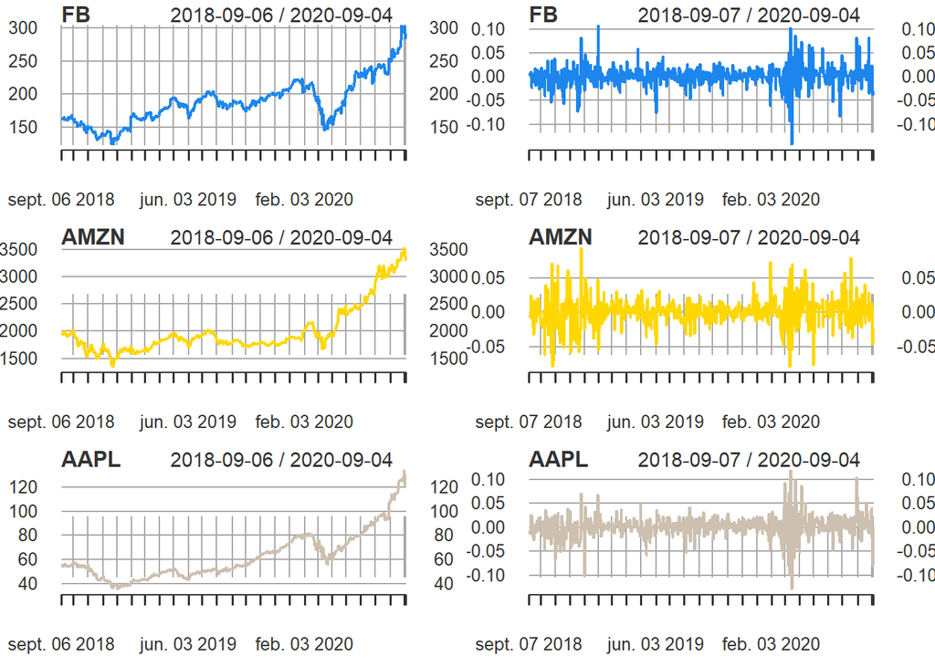

#### TBill Mensual

Esta sera necesaria para poder calcular el indice de sharpe por cada una de las acciones seleccionadas, esta se puede encontrar en la pagina oficial de la Reserva Federal (FRED): https://fred.stlouisfed.org/series/DTB3

```
## [1] 9.994504e-05
```

#### Indice de Sharpe por accion

Este indice mide numericamente la relacion Rentabilidad / Volatilidad Historica (desviacion standard) de cada accion, es decir, cuanto mayor sea el indice de Sharpe, mejor es la rentabilidad de la accion en relacion a la cantidad de riesgo que se ha tomado en la inversion.

```
##        FB
## 0.2576119
```

```
##      AMZN
## 0.2586672
```

```
##     AAPL
## 0.340564
```

#### Matriz de correlaciones

Aqui se observa la incidencia o el impacto que tiene una accion en relacion a otra

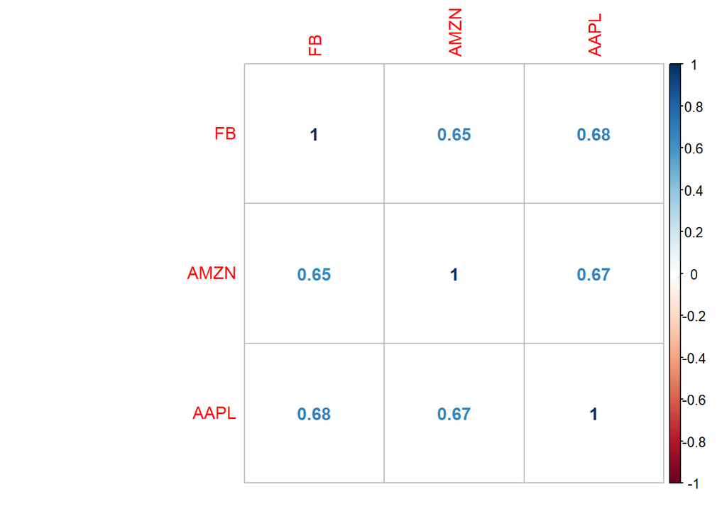

### Teoria del portafolio

#### Cartera de varianza del minimo global

```
##        FB      AMZN      AAPL
## 0.2510916 0.5050199 0.2438885
```

```
## Rentabilidad
##   0.02877232
```

```
## Volatilidad
##   0.0911879
```

### Grafica de los pesos

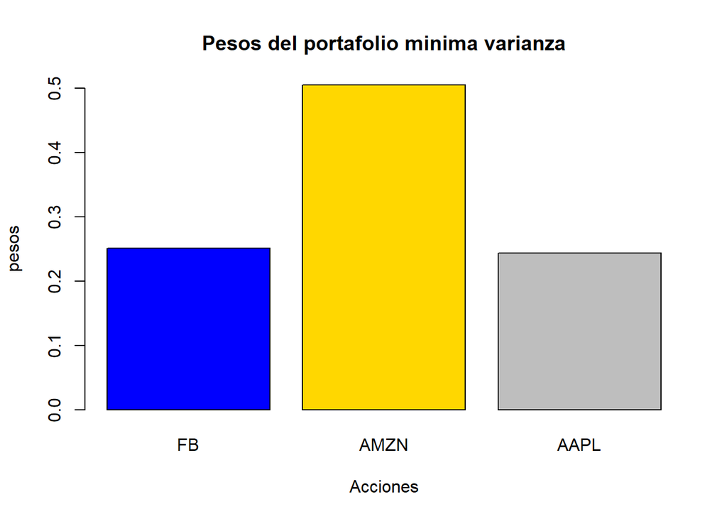

### Maximizacion con un portafolio

### Maximizacion con la rentabilidad igual a Facebook

#### Pesos del portafolio (FB)

```
##        FB      AMZN      AAPL
## 0.2803408 0.5681863 0.1514728
```

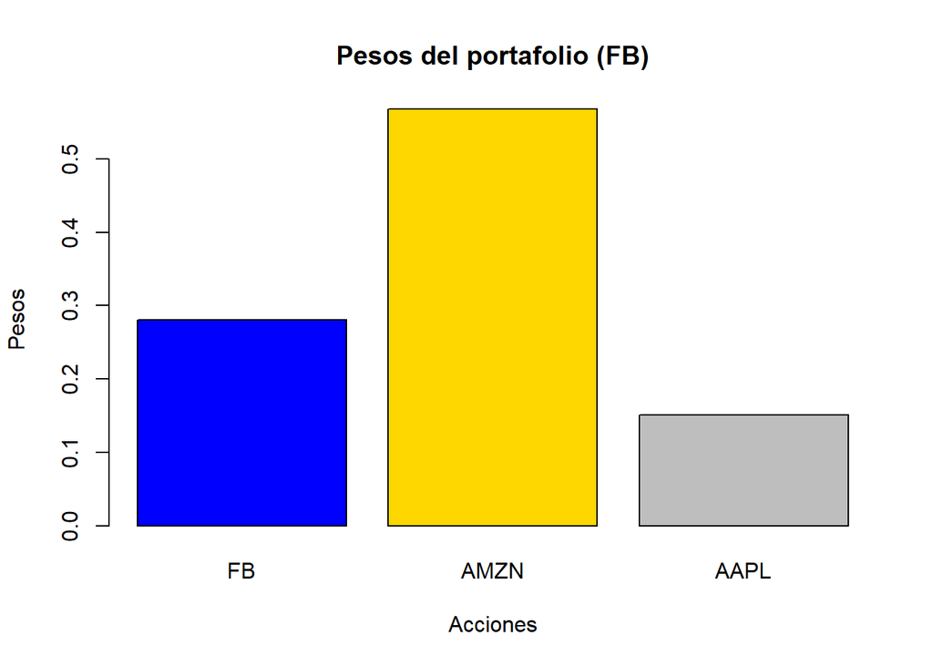

#### Rendimiento del portafolio (FB)

```
##            [,1]
## [1,] 0.02782034
```

#### Volatilidad del portafolio (FB)

```
##            [,1]
## [1,] 0.09144562
```

### Maximizacion con la rentabilidad igual a Amazon

#### Pesos del portafolio (AMZN)

```
##          FB        AMZN        AAPL
##  0.35171101  0.72231662 -0.07402763
```

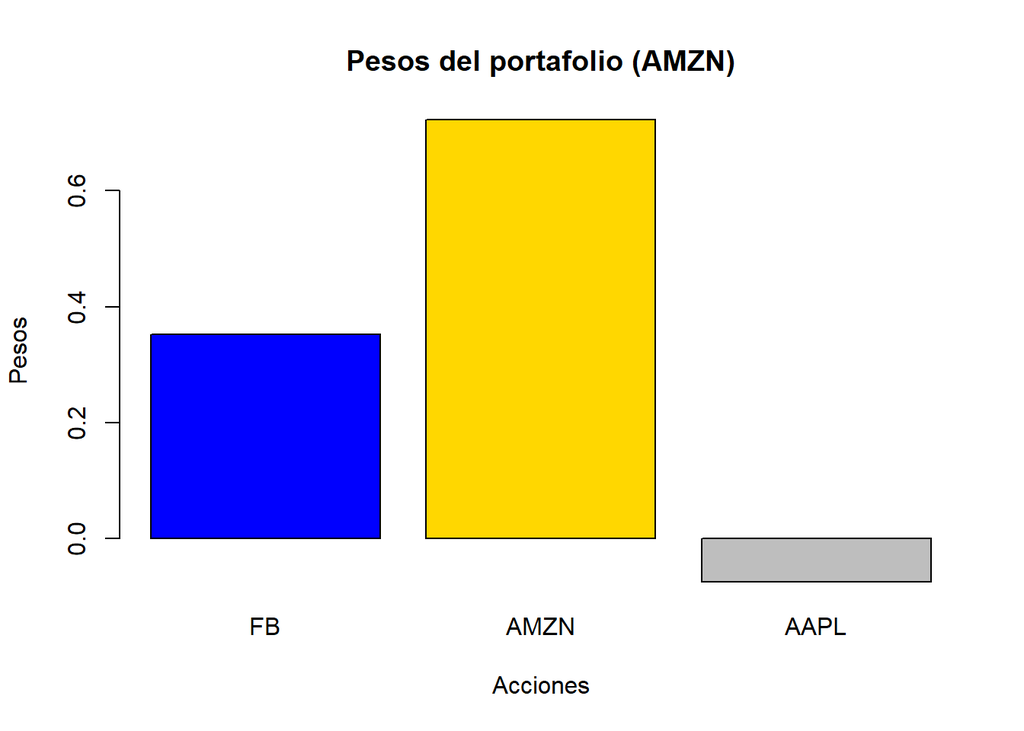

#### Rendimiento del portafolio (AMZN)

```
##            [,1]
## [1,] 0.02549747
```

#### Volatilidad del portafolio (AMZN)

```
##            [,1]
## [1,] 0.09419257
```

### Maximizacion con la rentabilidad igual a Apple

#### Pesos del portafolio (AAPL)

```
##          FB        AMZN        AAPL
##  0.01262576 -0.00996831  0.99734255
```

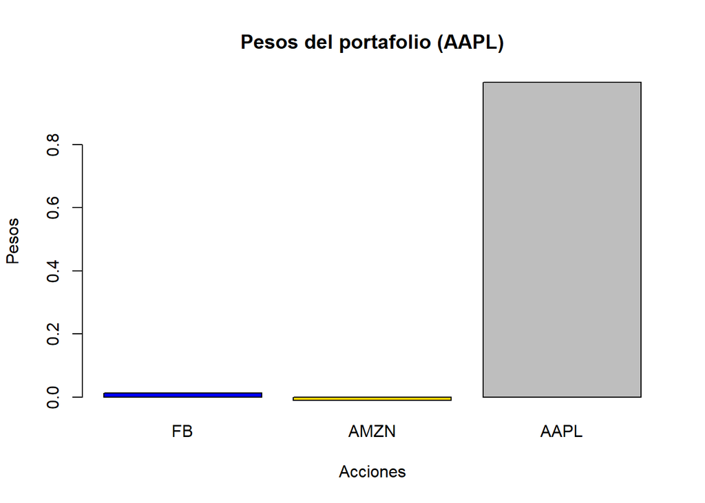

```
##            [,1]
## [1,] 0.03653363
```

```
##           [,1]
## [1,] 0.1069758
```

#### Pesos del portafolio (RO)

```
##         FB       AMZN       AAPL
##  0.4622428  0.9610199 -0.4232627
```

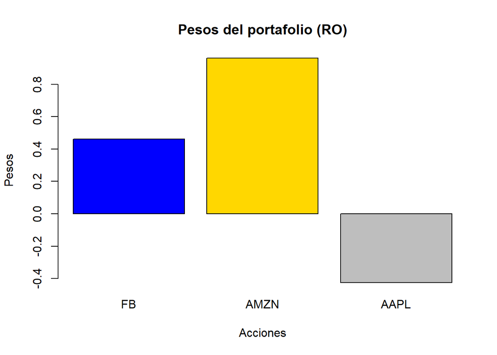

#### Rentabilidad del portafolio (RO)

```
##        [,1]
## [1,] 0.0219
```

#### Volatilidad del portafolio (RO)

```
##           [,1]
## [1,] 0.1037697
```

### Grafico de portafolios

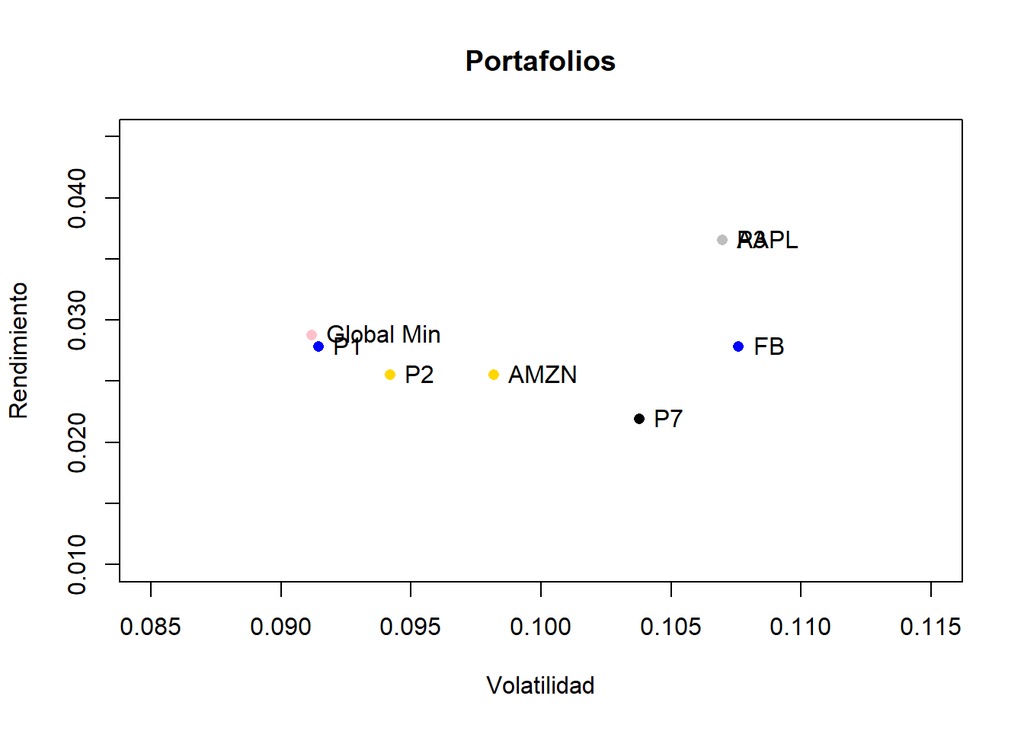

### Curva de frontera eficiente

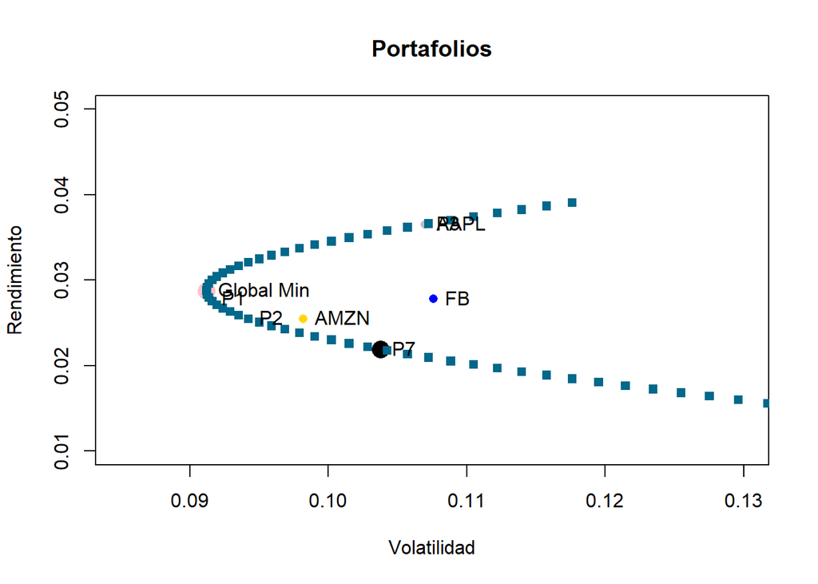

### Linea CAL

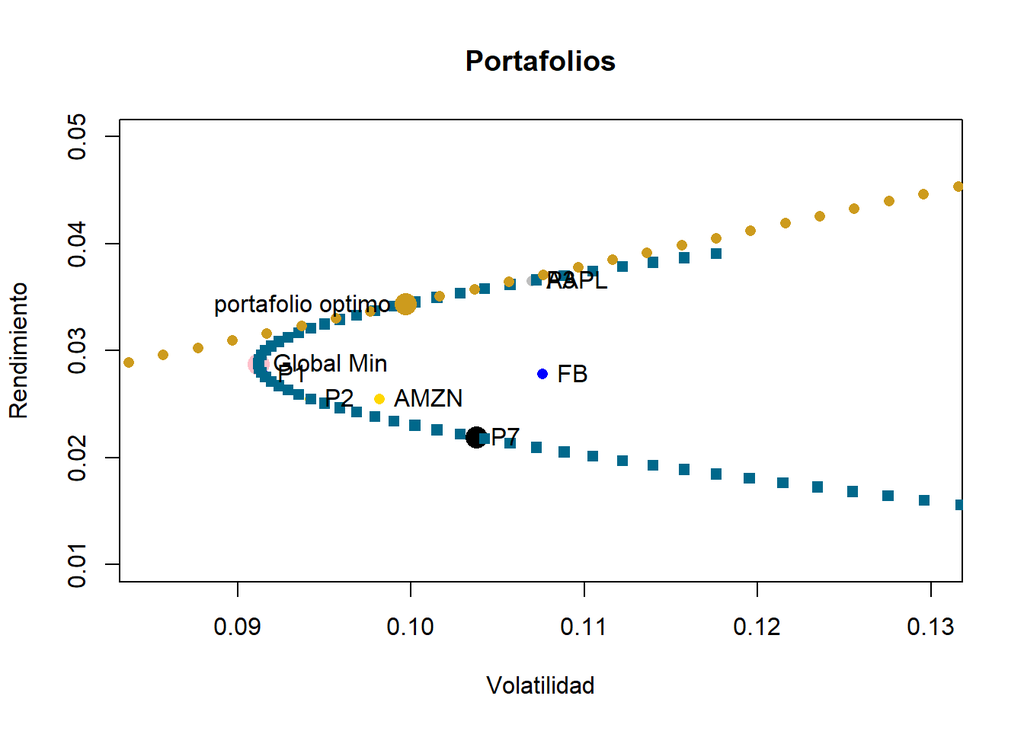

## CAPM

Creando matriz de precios al cierre

```
## [1] "DGS1MO"
```

```
## [1] "^GSPC"
```

```
##   FB.Close AMZN.Close AAPL.Close GSPC.Close     DGS1MO
##          0          0          0          0          0
```

#### Calculo de los betas de forma rapida

```
##      GSPC        FB      AMZN      AAPL
## 1.0000000 1.0232770 0.8499362 1.1767013
```

```
##           FB         AMZN         AAPL
## 0.0008936689 0.0008617747 0.0012547640
```

#### Calculo de los excesos de retorno (over riskfree rate)

### CAPM de cada uno de los activos

#### - Generando un primer CAPM para FB

```
##  [1] "coefficients"  "residuals"     "effects"       "rank"
##  [5] "fitted.values" "assign"        "qr"            "df.residual"
##  [9] "xlevels"       "call"          "terms"         "model"
```

```
##
## Call:
## lm(formula = erfb ~ ergspc)
##
## Residuals:
##       Min        1Q    Median        3Q       Max
## -0.073064 -0.009008 -0.000536  0.008242  0.098476
##
## Coefficients:
##              Estimate Std. Error t value Pr(>|t|)
## (Intercept) 0.0009878  0.0007713   1.281    0.201
## ergspc      1.0280662  0.0452864  22.701   <2e-16
##
## Residual standard error: 0.01704 on 501 degrees of freedom
## Multiple R-squared:  0.5071, Adjusted R-squared:  0.5061
## F-statistic: 515.4 on 1 and 501 DF,  p-value: < 2.2e-16
```

#### - Generando un primer CAPM para AMZN

```
##  [1] "coefficients"  "residuals"     "effects"       "rank"
##  [5] "fitted.values" "assign"        "qr"            "df.residual"
##  [9] "xlevels"       "call"          "terms"         "model"
```

```
##
## Call:
## lm(formula = eramzn ~ ergspc)
##
## Residuals:
##       Min        1Q    Median        3Q       Max
## -0.064294 -0.008269 -0.001362  0.007249  0.088138
##
## Coefficients:
##              Estimate Std. Error t value Pr(>|t|)
## (Intercept) 0.0003792  0.0007628   0.497    0.619
## ergspc      0.8612224  0.0447848  19.230   <2e-16
##
## Residual standard error: 0.01685 on 501 degrees of freedom
## Multiple R-squared:  0.4247, Adjusted R-squared:  0.4235
## F-statistic: 369.8 on 1 and 501 DF,  p-value: < 2.2e-16
```

#### - Generando un primer CAPM para AAPL

```
##  [1] "coefficients"  "residuals"     "effects"       "rank"
##  [5] "fitted.values" "assign"        "qr"            "df.residual"
##  [9] "xlevels"       "call"          "terms"         "model"
```

```
##
## Call:
## lm(formula = eraapl ~ ergspc)
##
## Residuals:
##       Min        1Q    Median        3Q       Max
## -0.071361 -0.007609 -0.000015  0.007455  0.093821
##
## Coefficients:
##              Estimate Std. Error t value Pr(>|t|)
## (Intercept) 0.0018740  0.0006235   3.006  0.00278
## ergspc      1.1806618  0.0366044  32.255  < 2e-16
##
## Residual standard error: 0.01377 on 501 degrees of freedom
## Multiple R-squared:  0.675,  Adjusted R-squared:  0.6743
## F-statistic:  1040 on 1 and 501 DF,  p-value: < 2.2e-16
```

### Graficas de CAPM por accion

[figure not shown]

```
##        FB      AMZN      AAPL
## 1.0280662 0.8612224 1.1806618
```

## Indice de Treynor

#### - Para cada uno de los activos

Podemos concluir que cuanto mayor sea el ratio de Treynor mejor habra sido la gestion del fondo en el pasado.

```
##      IT FB
## 0.02696363
```

```
##    IT AMZN
## 0.02949008
```

```
##   IT AAPL
## 0.0308587
```

#### - Para el portafolio optimo

```
##        [,1]
## [1,] 0.0304
```

#### - Para el portafolio minimo global

```
##  IT MG
## 0.0292
```

#### - Para el portafolio de preferencia

```
##        [,1]
## [1,] 0.0271
```